# S&D Survey Exploration

Tom Kremer

5/5/2022

## Intro

Notebook exploring some aspects of the supply & demand survey data.

Last updated: 2022-05-06

## Number of responses and animals

This is just to give some context to all subsequent figures. Covers the number of survey responses, current animals, and animals left in the last 5 years.

| Study Community | Responses | # Current Animals Total | # Current Animals Dogs | # Current Animals Cats | # Left Last 5 Years Total | # Left Last 5 Years Dogs | # Left Last 5 Years Cats |
| --- | --- | --- | --- | --- | --- | --- | --- |
| Cabot, Arkansas | 864 | 1793 | 1108 | 685 | 1488 | 926 | 562 |
| Dallas | 993 | 1687 | 1089 | 598 | 1429 | 872 | 557 |
| Fresno, CA | 875 | 1875 | 1145 | 730 | 1624 | 907 | 717 |
| Metro Detroit | 1113 | 1555 | 878 | 677 | 1658 | 840 | 818 |
| New Hampshire | 871 | 1349 | 664 | 685 | 872 | 446 | 426 |
| Palm Valley | 629 | 1418 | 934 | 484 | 1070 | 701 | 369 |
| Washington DC | 973 | 1354 | 799 | 555 | 1353 | 738 | 615 |

## Animals left home per response by county

The following figure shows the number of animals/dogs/cats (see different tabs) left home in the last 5 years divided by the number of responses per county.

Minor preprocessing notes:

1. Responses with more than 50 animals leaving home in the last 5 years were excluded (I just chose an arbitrary threshold, which removed 5 responses; if the threshold was 30 it would exclude 4 more responses when considering only dogs, for example).
2. The figures only shows data for the 17 (of 119) counties that had more than 100 survey responses. If the threshold was 50, we would have 30 counties.

Things that stood out: California and Texas counties star, with Hidalgo (TX), Tulare (CA) and Fresno (CA) at the top across species; Tulare high in both species, Hidalgo leading the dogs, Fresno primarily cats. Cabot high up for dogs as well.

### All Species

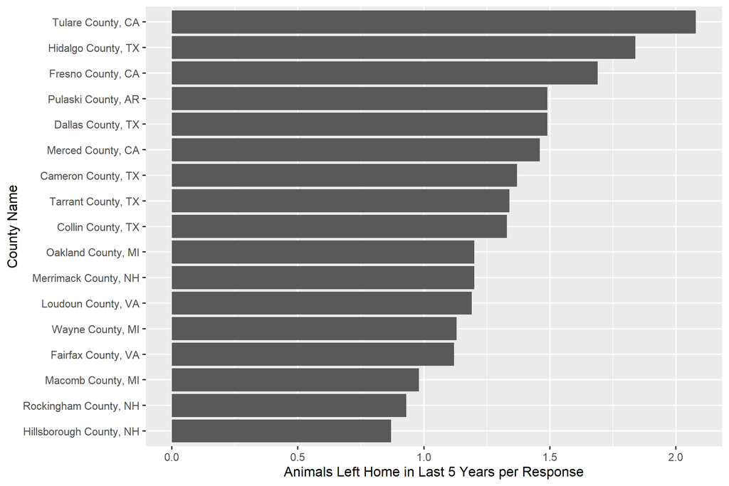

### Dogs

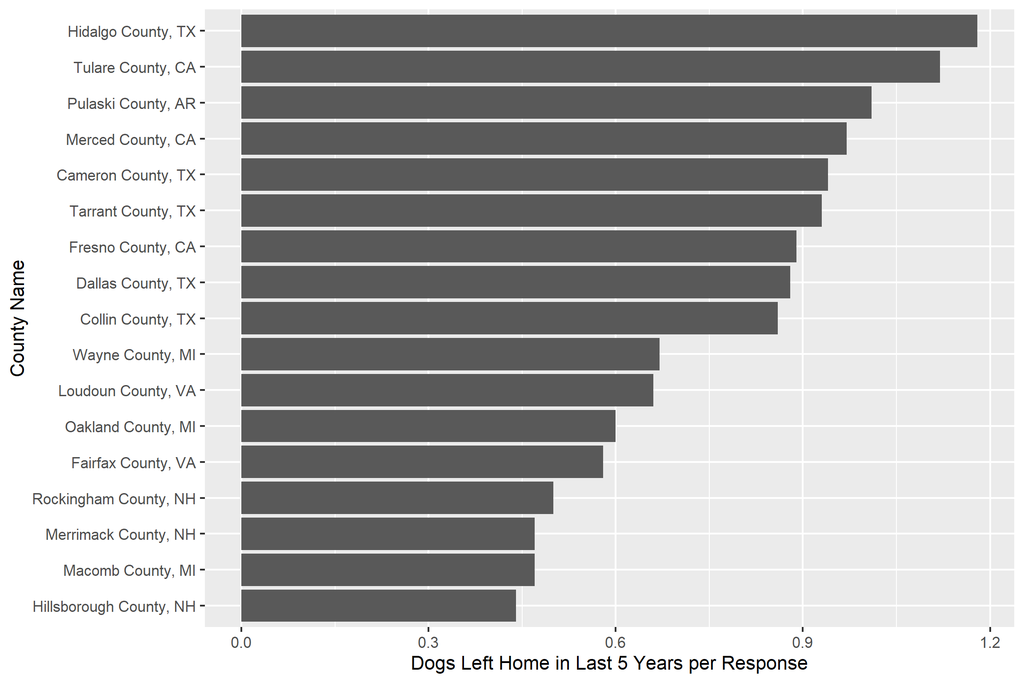

### Cats

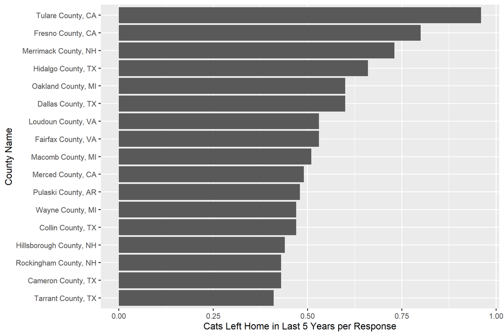

## Breakdown of ways animals left home by study community

The % of animals who left home in a particular way within each study community. This time excludinig >50 animals left home responses but including all counties.

Some notes:

1. Significant variation in the % put to sleep - from a low of 8-12% in PVAS, Fresno, Cabot (where most animals left generally) to highs 22-32% in DC, Detroit, and NH. These numbers are for all species, but the gap exists when looking at dogs and cats separately as well.
2. While a smaller margin, these two groups also differ in the % of animals given away in the other direction - 23-24% in Fresno, Cabot, PV and 15-19% in DC, Detroit, DC.
3. NH stands out with lowest running away percentage (8%) compared to all other communities (16-24%). Even more intense when looking only at dogs - 1.5% in NH, 14-20% in all the others.

### All Species

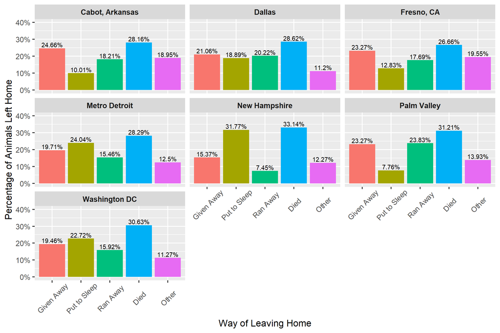

### Dogs

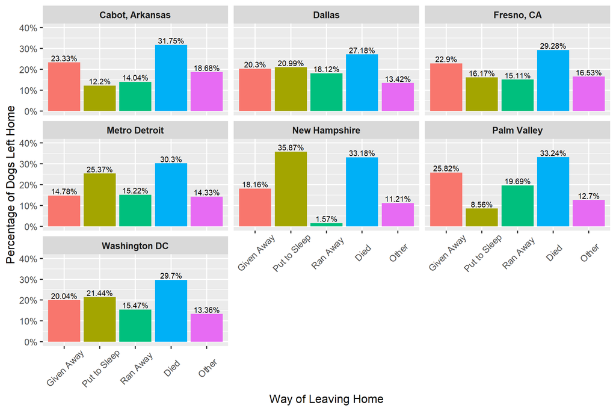

### Cats

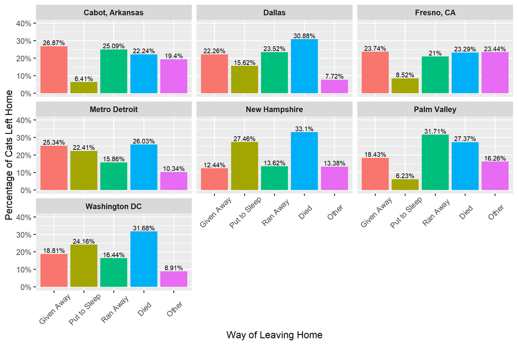

## Breakdown of ways of leaving home by income bracket

This is the same as the previous section, but with income brackets being the grouping variable.

The % differences aren’t very pronounced in all cases, but it seems like the % of animals given away is higher for lower income brackets and decreases with income (not monotonically, roughly), whereas the % of animals put to sleep (and somewhat also those dying) shows the opposite trend. Which makes sense to me. % running away is highest for <15k but 2nd highest for 150k+. This trend is true for cats and dogs.

### All animals

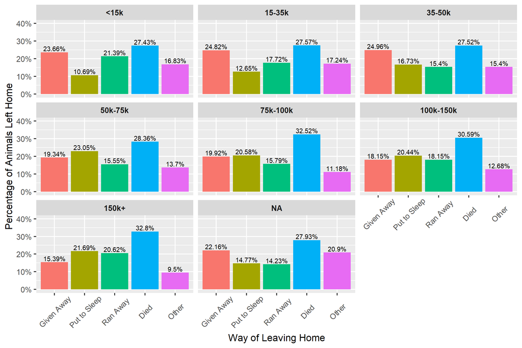

### Dogs

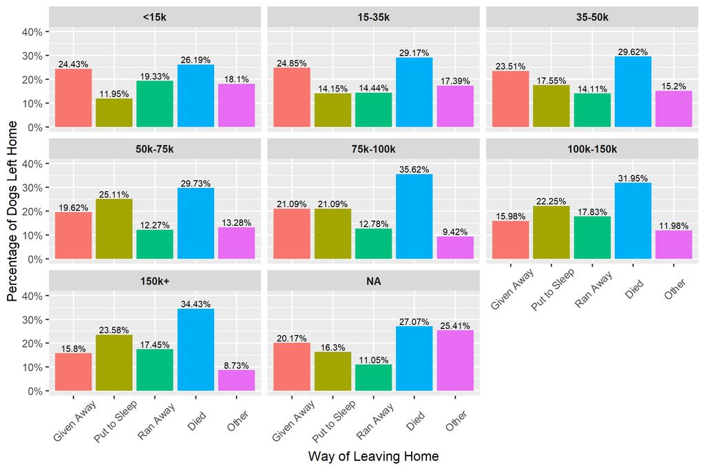

### Cats

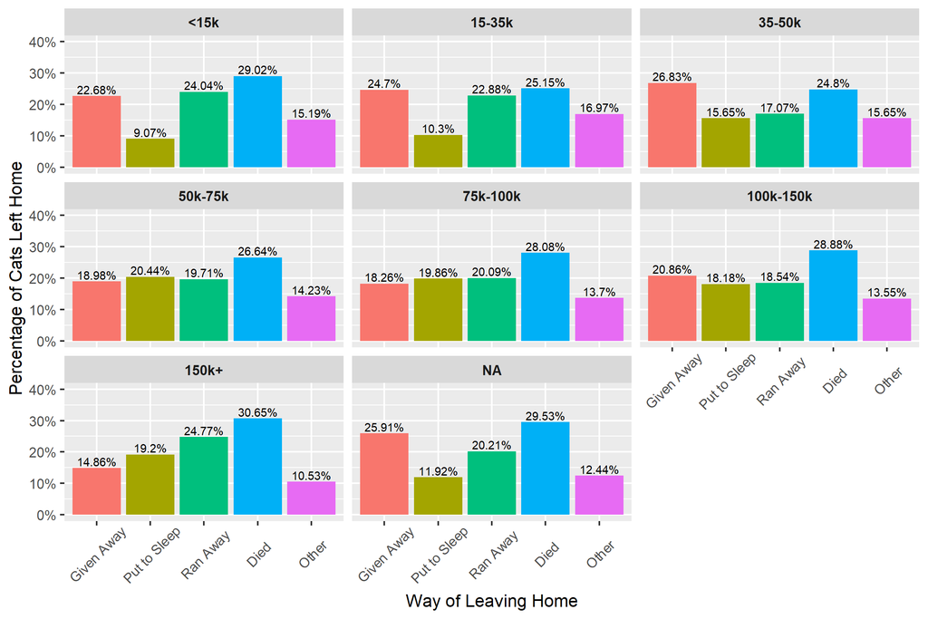

## Reason animals are given away by study community

I wanted to look at the reasons cited for giving away animals when that happened. 1585 animals had a non-null reason listed, in all of which the owner’s survey also indicated an animal given away (no mismatches here). In addition, out of the 5935 NA reason, 1200 animals (associated with 543 respondents) were listed without reason despite owner indicating an animal was given away in their response.

So out of 1416 people who indicated giving away 2785 animals in total, 873 people listed a reason for 1585 animals, i.e. reasons are available for 57% of given away animals and given by 62% of people who gave away animals. I’m not sure if you think it’s a good enough percentage, but I went ahead anyway.

Some notes (all species):

1. NH stands out for housing (‘lease restrictions’), accounting for 22% of animals given away (24% of dogs), followed by Cabot and Dallas (16%).
2. Detroit and DC stand out with behavior being the leading cause (24 and 21%).
3. Cabot, Fresno, and PVAS have the highest percentages of animals given away because they were temporarily held (25-28%, vs. 18-20% in the other communities).

When looking only at dogs, PVAS temporary % is much lower, cost (23%) and behavior (20%) are the main reasons. Likewise, for cats only, the temporary % is higher in all three (30-35%) while remaining lower (14-20%) in the other communities.

### All species

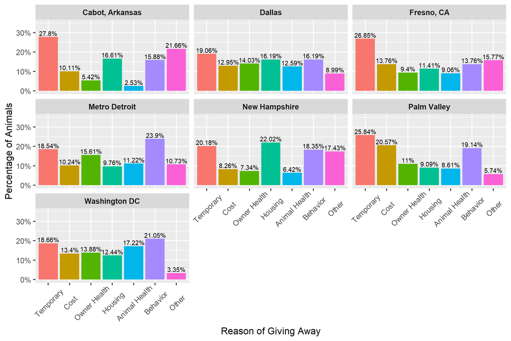

### Dogs

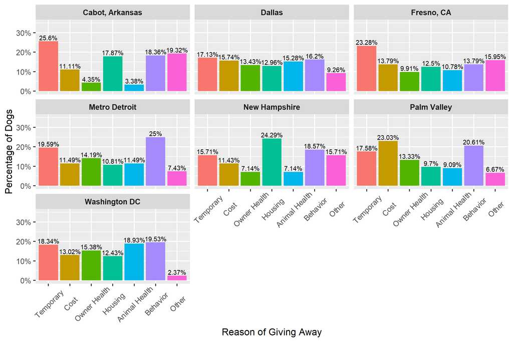

### Cats

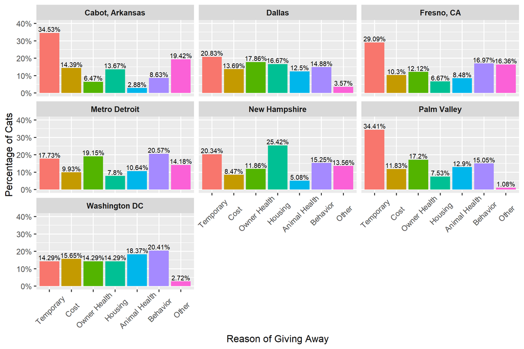

## Who were animals given to by study community

This is similar to the above section, but looking at who the animal was given to rather than the reason listed for giving the animal away. Whenever a reason was listed a destination was also listed, so the percentages of completion are the same as the above (57% of animals given away and 62% of people who gave away animals have completed these).

DC and Detroit stand out as having 51% and 54% of animals given to friends or relatives as opposed to 63% in Dallas and 69-74% in all others. The difference is animals given to rescues or shelters.

### All species

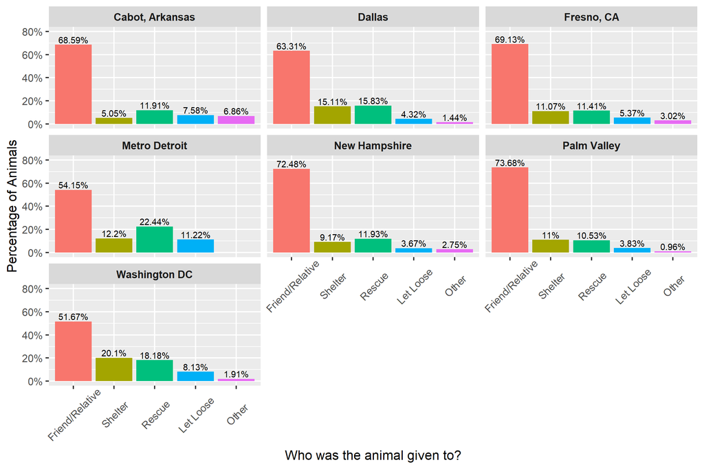

### Dogs

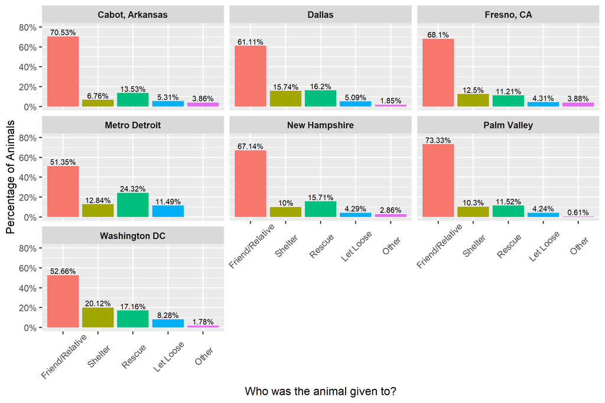

### Cats

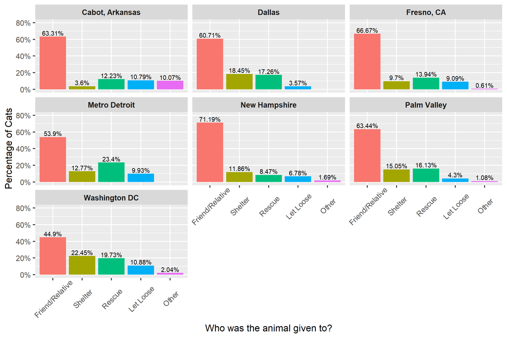